# STAT 240 Final Project

## **Team Members**

Matthew Chiang, Siyu Huang, Vishnu Yaragadda

## **Introduction**

“People cry when their team lose, and they cry even more when their team wins.” Our team decided to conduct our analysis on the La Liga Football League as it is one of the most influential soccer leagues in the world. The league also has the most exciting rivalry in history: Real Madrid vs Barcelona. Our team members are also fans of this soccer league and we decided to conduct research on the La Liga data. Throughout history, only nine different teams have been crowned champions, and we are curious about what makes those teams so special. More specifically, what are some of their common characteristics that result in them always performing so well.

We theorize that three reasons why those teams perform so well is that the total amount of goals per season of said top teams keeps increasing in a consistent or linear manner, the top scorer for the teams that perform well have a higher contribution to the total goals when compared to the rest of the league, and that the possession rate for those top teams are also much higher.

## **Background**

> Raw Data:

We found data for the La Liga Soccer League. Each season from 1988-2020, there are multiple sets of data ranging from team rankings, top scorers, standard squad statistics, team goalkeeping, team shooting, to statistics on individual players. We selected three sets of data:

- League Table: includes team rankings, total wins, loses, goals for, goals against, etc.
- Squad Standard Stats: includes general performance statistics of each team.
- Squad Goalkeeping: includes performance statistics for the goalkeeping of each team.

> Final Data:

We had to collect the above data for the seasons between 1988-2020. We combined all of the data into one large dataframe called allData by the team name and created a year column to keep track of which teams data corresponds to which year. Then, we trimmed most of the variables in that large data set away and only selected the ones that were used in the analysis.

**allData** contains the variables described below:

| Variable | Description |
| --- | --- |
| year | Season year |
| Rk | Rank of each team for that season |
| Squad | Team Name |
| W.x | Number of wins for that team during season |
| L.x | Number of losses for that team during season |
| D.x | Number of draws for that team during season |
| GF | Total number of goals the team scored during season |
| GA.x | Total number of goals the team conceded during season |
| Top.Team.Scorer | Name of team’s top scorer during season |
| Poss | Average Rate of Possession of the ball during season |
| Saves | Total number of saves the team had during season |

> Data Citation:

“La Liga Seasons”, Real Federación Española de Fútbol, 7th April 2020, https://fbref.com/en/comps/12/history/La-Liga-Seasons

> Data Caveats:
- To perform our analysis we considered all teams data, not just the teams that are currently in the league.
- The data set we found does not have data for Poss or Saves before the year 2000. In parts of analysis that use those metrics, we used the data for the top 3 teams of each season instead of just the champion team. This allowed us to have a more accurate sample size.

## **Analysis**

> Question 1: First, we wanted to test our claim that we can make a linear regression model for the amount of total goals of the top 3 teams of the current season.

First, we look at the number of Goals of the top 3 teams for each season over the years.

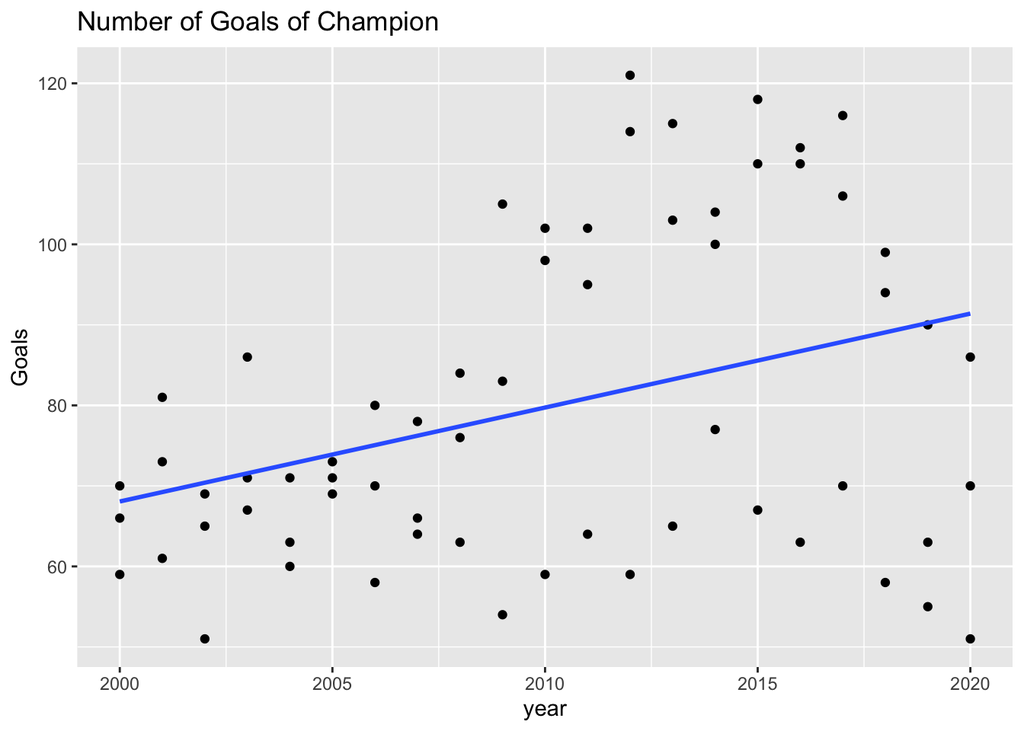

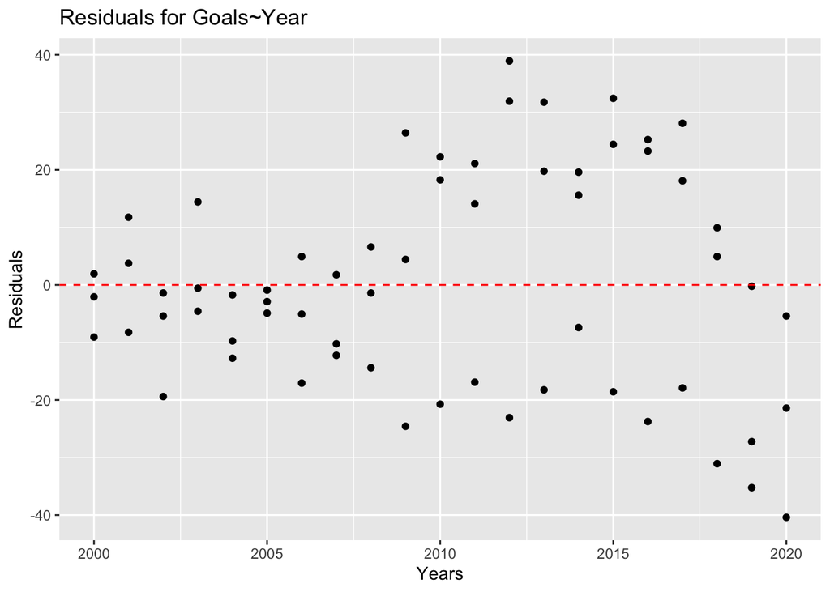

$$Goals = 1.1667*year - 2265.2698$$
Now, we state our 95% confidence interval for the slope of the linear regression.

So, according to our calculations, our 95% confidence interval is between 0.3864 and 1.9468. After conduction some research we found that because 0 does not exist within our confidence interval, this shows that there exists significant evidence of a linear relationship.

> Next, we wanted to look at the second part of our thesis about how a top team has a higher proportion of goals from their top scorer compared to the rest of the league.

For each champion team of each season, they have a top scorer that scores more goals than other players in the team and we believe that this consists of a sizable proportion of total goals of the team compared to other teams.

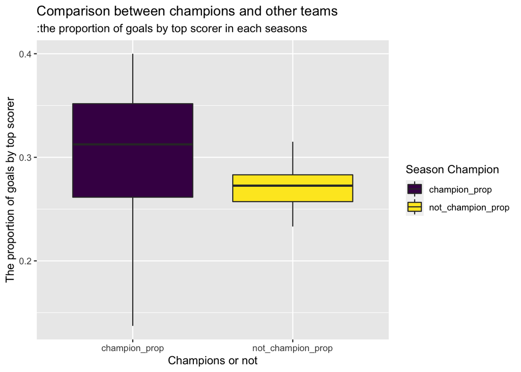

From the observation of the graph, we assume that the proportion of top scorer’s goals in champions teams tend to be higher than those of non-champions teams. To verify our guess, we can perform a hypothesis test.
$$H_0: p_0 = p_1$$
$$H_a: p_0 > p_1$$
where $\mu_0$ is the proportion of top scorer’s goals over total goals for champions teams, and $\mu_1$ is the top scorer’s goals over total goals for non-champions teams. To carry out this test, we will consider a two-sample z-test with the following test statistic:
$$Z = \frac{p_0-p_1}{\sqrt{\frac{s_0^2}{n_0} + \frac{s_1^2}{n_1}}}$$

After performing the test we get the following results:

We perform the hypothesis test where the null hypothesis is that the proportions are equal. After doing the z-test, we found that the p-value is 0.0002179 and it is statistically significant so that we can reject the null hypothesis. Therefore, The proportion of top scorer’s goals of all goals in champions teams tend to be higher than those of non-champions teams which supports our thesis.

> Now, our last part of the thesis states that the possession rate of a top team is higher than the rest of the league.

It’s reasonable to assume that a winning team would have a higher possession rate as that would give the team more chances to score. So, we wanted to test that:

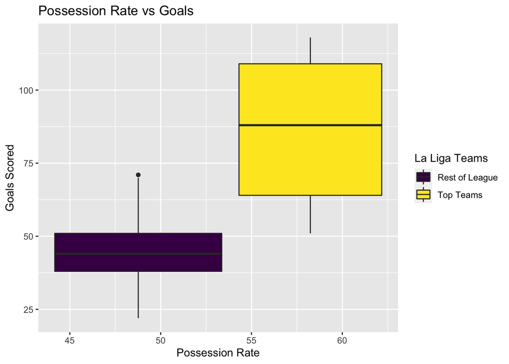

The graph above supports our initial claim as the Top Teams have a much higher possession rate and thus end up with more goals scored. Now, we want to conduct a hypothesis test to reaffirm our claim that teams with high possession rates tend to do better.

We can frame this as a hypothesis test described as follows:
$$H_0: \mu_0 = \mu_1$$
where $\mu_0$ is the mean possession rate for the rest of the league, and $\mu_1$ is the mean possession rate for the top teams.

$$H_a: \mu_0 < \mu_1$$

To carry out this test, we will consider a two-sample test with the following test statistic:
$$T = \frac{(\mu_0-\mu_1)}{\sqrt{\frac{s_0^2}{n_0} + \frac{s_1^2}{n_1}}}$$
where under the null $\mu_0 - \mu_1 = 0$, $n_i$ is the sample size for group $i=0,1$, and $s_i$ is the standard deviation of group $i$.

Since we are estimating the standard error, we will be using a t-distribution rather than a normal distribution.

After performing our t-test we get the following results:

- $T = -4.8765$
- ${DegreesOfFreedom} = 19.6$
- $PValue = 4.82*10^{-5}$

Using a t-distribution with 19.6 degrees of freedom, we calculate a p-value on the order of $10^{-5}$ suggesting that we can reject the null hypothesis. This rejections means we have concluded that the mean possession rate for the top teams is greater than the mean possession rate for the rest of the league.

## Discussion

In the world of soccer, everything is unpredictable and there are a lot more factors that could affect the trend of a season. For example, transfers could bring new players that strengthen the team and the injuries of key players could hinder a team’s success. It is even more difficult to predict the winner of a future season, but we can definitively say a few things about top performing teams.

One shortcoming of our project was that we had very limited amounts of data. Although we had league data from 1988 through 2020, certain metrics were not logged before 2000, so for parts of our analysis where we used data that was only available from 2000 and later, we had to account this by analyzing the top 3 teams instead of just the champion team. Consequently, our results may not be as accurate. Another shortcoming is that we tended to focus on only three aspects of a soccer team, namely goals, possession and top scorer . But, in reality, there might be a lot more variables that come into play. For example, we could consider each team’s overall offensive and defensive ratings to see how that has affected the winners of each season throughout history. This question could be done in the future to expand our analysis.